# Stat 245 – Test 3

Sharon Evangeline Velpula

December 06, 2022

### Reading in Data

```r
myDataSet <- read.csv("https://osf.io/jtkn9/download")

myDataSet <- myDataSet |>
  arrange(author.name)

head(myDataSet)
```

```
##   author.name no.of.papers Gender indegree strength.mean
## 1           1           28      M       58      1.827586
## 2           2            6      M        8      1.500000
## 3           3          103      M      110      2.100000
## 4           4            3      F        5      1.800000
## 5           5          170      M      180      2.827778
## 6           6           91      M      115      2.400000
##   clusteringcoefficient.global triangles demoninator first.year last.year
## 1                    0.5772077      2340        4054       1988      2017
## 2                    0.4375000        21          48       1997      2003
## 3                    0.2029874      1590        7833       1987      2018
## 4                    1.0000000        60          60       1997      2002
## 5                    0.1969773      7416       37649       1983      2018
## 6                    0.5225603      8964       17154       1986      2018
##   n.years first.lastauthor second.lastauthor third.lastauthor gap Time.to.PI
```

[output cut: 20 more lines]

### Rationale

I chose author.name as my random effect variable since it is a variable of identity. This variable is specific to each author and might affect our response variable, Indegree, which is the size of an author’s collaborative network. To account for that dependence, I would like to add it as a random effect variable in my model.

### Fitting without RE

```r
mC1 <- glmmTMB(indegree ~ no.of.papers*Gender + n.years, data = myDataSet,
family = nbinom1(link = 'log'), na.action = 'na.fail')


mC2 <- glmmTMB(indegree ~ no.of.papers*Gender + n.years, data = myDataSet,
family = nbinom2(link = 'log'), na.action = 'na.fail')

BIC(mC1, mC2)
```

```
##     df      BIC
## mC1  6 9102.850
## mC2  6 9052.789
```

### Fitting with RE

```r
mC1_new <- glmmTMB(indegree ~ no.of.papers*Gender + n.years + (1|author.name), data = myDataSet,
family = nbinom1(link = 'log'), na.action = 'na.fail')

mC2_new <- glmmTMB(indegree ~ no.of.papers*Gender + n.years + (1|author.name), data = myDataSet,
family = nbinom2(link = 'log'), na.action = 'na.fail')

BIC(mC1_new, mC2_new)
```

```
##         df      BIC
## mC1_new  7 9037.486
## mC2_new  7 9035.099
```

### Summary

```r
summary(mC2_new)
```

```
##  Family: nbinom2  ( log )
## Formula:
## indegree ~ no.of.papers * Gender + n.years + (1 | author.name)
## Data: myDataSet
##
##      AIC      BIC   logLik deviance df.resid
##   9001.2   9035.1  -4493.6   8987.2      928
##
## Random effects:
##
## Conditional model:
##  Groups      Name        Variance Std.Dev.
##  author.name (Intercept) 0.1402   0.3744
## Number of obs: 935, groups:  author.name, 935
##
## Dispersion parameter for nbinom2 family (): 4.95
##
## Conditional model:
##                       Estimate Std. Error z value Pr(>|z|)
## (Intercept)           1.982226   0.079782  24.845  < 2e-16 ***
## no.of.papers          0.016563   0.001090  15.194  < 2e-16 ***
## GenderM               0.310578   0.067661   4.590 4.43e-06 ***
## n.years               0.043198   0.003099  13.940  < 2e-16 ***
## no.of.papers:GenderM -0.005285   0.001108  -4.771 1.83e-06 ***
## ---
## Signif. codes:  0 '***' 0.001 '**' 0.01 '*' 0.05 '.' 0.1 ' ' 1
```

The random effect variance estimate is 0.1402 and it explains the variability in the size of an author’s collaborative network by the given predictors number of papers, number of years and Gender, across all authors. Since the estimate is closer to 0, it looks like the model partially explains the variance in the collaborative size of authors using the predictors.

### Assessment without RE

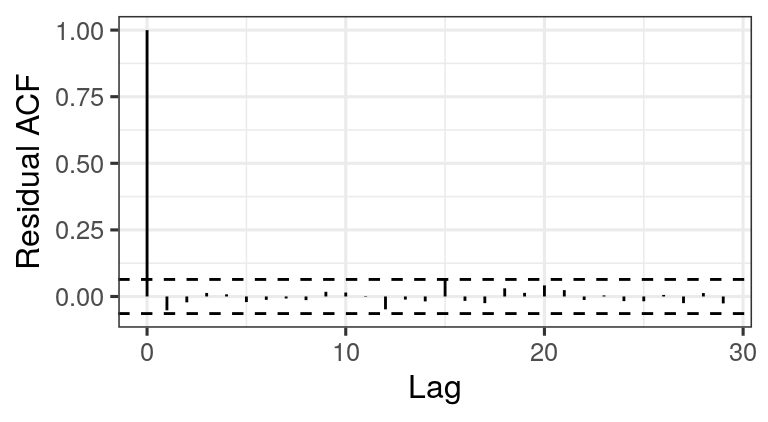

```r
s245::gf_acf(~mC2)
```

### Assessment with RE

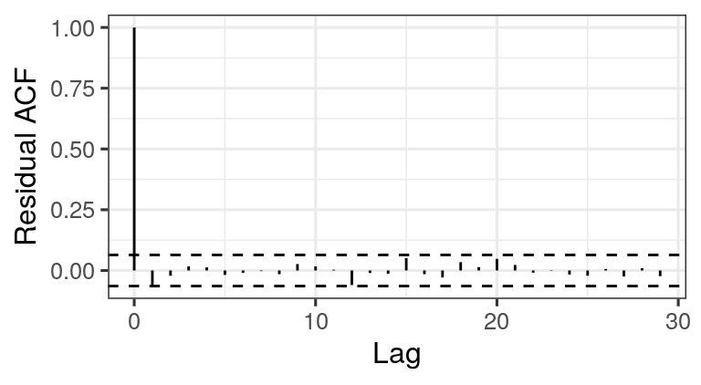

```r
s245::gf_acf(~mC2_new)
```

Looking at the ACF plots, it seems that both the models, with RE and without RE meet the condition. There is no ACF value that exceeds the confidence bounds, so from this plot, there is no evidence of non-independence in the residuals. On analyzing closely, the lags for the model with RE seem to be a little longer than that of the model without RE. But the difference is too small and most importantly, all the lags lie within the bounds so adding the random effect variable did not change anything significantly.

### Predictions

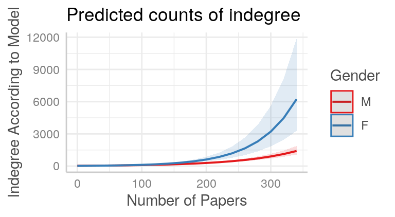

```r
require(ggeffects)
pred_plot_data_2 <- ggpredict(mC2_new, terms = c('no.of.papers', 'Gender'))
plot(pred_plot_data_2) %>%
gf_labs(x = 'Number of Papers', y = 'Indegree According to Model')
```

### Selection and Conclusion

```r
library(MuMIn)
dredge(mC2_new, rank = 'BIC')
```

```
## Global model call: glmmTMB(formula = indegree ~ no.of.papers * Gender + n.years +
##     (1 | author.name), data = myDataSet, family = nbinom2(link = "log"),
##     na.action = "na.fail", ziformula = ~0, dispformula = ~1)
## ---
## Model selection table
##    cnd((Int)) dsp((Int)) cnd(Gnd) cnd(n.yrs) cnd(no.of.ppr) cnd(Gnd:no.of.ppr)
## 16      1.982          +        +    0.04320        0.01656                  +
## 7       2.137          +             0.04624        0.01209
## 8       2.106          +        +    0.04592        0.01199
## 14      2.825          +        +                   0.02262                  +
## 5       3.150          +                            0.01637
## 6       3.097          +        +                   0.01617
## 4       1.616          +        +    0.08993
## 3       1.718          +             0.09258
## 1       4.350          +
## 2       3.462          +        +
##    df    logLik     BIC   delta weight
## 16  7 -4493.608  9035.1    0.00  0.997
## 7   5 -4506.358  9046.9   11.82  0.003
## 8   6 -4505.322  9051.7   16.59  0.000
## 14  6 -4577.249  9195.5  160.44  0.000
## 5   4 -4598.343  9224.0  188.95  0.000
## 6   5 -4596.395  9227.0  191.89  0.000
## 4   5 -4759.836  9553.9  518.78  0.000
## 3   4 -4768.223  9563.8  528.71  0.000
## 1   3 -5050.734 10122.0 1086.89  0.000
## 2   4 -5056.351 10140.1 1104.97  0.000
## Models ranked by BIC(x)
## Random terms (all models):
##   cond(1 | author.name)
```

As we can see, model 16 seems to be the best model with number of years, number of papers, gender and the interaction between Gender and number of papers. It has the lowest BIC value with a delta value of 11.82 between that and the model with the next lowest BIC. Compared to most of the models, the delta value is quite high ranging between 100-1200. So our choices would be models 7, 16 and 8 among which model 16 has the lowest BIC, hence the best choice for us here.

### Extra

What are the pros and cons of the style of tests used in this course this fall?

I actually loved this style of testing. I took STAT 243 last semester and the tests were written, closed-book and with strict time limits. It was hard because there were so many practical aspects such as R code that I had to memorize instead of being able to use RStudio. With this testing style, I was able to really understand the test, try different techniques and then go forward with the best version of my solution. Having a week to do this test really helped me understand the concepts even better and I thoroughly enjoyed doing all the tests. The best part for me was having the opportunity to revise the tests because sometimes, I look at my test feedback, remember it for a few days and I forget about it. But revising it just makes it stay in my mind and I learn much better. If you asked me whether this style should be kept or changed in future classes, I would say please keep it!